# Lengths of Songs by The Beatles

Jim Albert

### The Beatles

The Beatles were one of the most popular musical groups in the history of popular music. I’ll introduce several graphs to explore the lengths of their songs and see how the lengths changed during their tenure. In particular, I’ll use this example to illustrate the benefits of interactive graphics.

First I read a dataset that contains the song title, year, and length (in seconds) for all 211 songs that they released during their career. (I found this dataset from Aaron Krerowicz at https://www.aaronkrerowicz.com/beatles-blog/its-been-a-long-long-long-time-duration-in-beatles-songs .)

### Reading the Data

Also I load in the tidyverse suite of packages.

```r
library(tidyverse)
beatles <- read_csv("beatles_songs_durations.csv")
```

### Basic Static Graph

Here is a basic jittered plot of the lengths against the year.

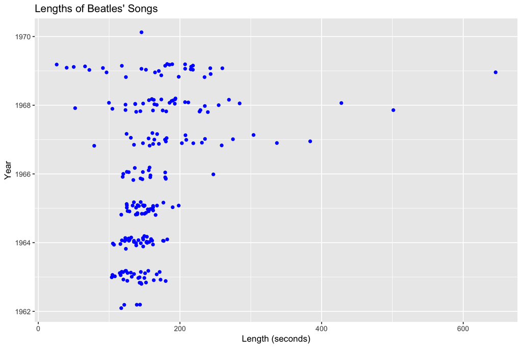

```r
ggplot(beatles,
       aes(Year, Length)) +
       geom_jitter(aes(text = Title),
                   width = 0.2, color = "blue") +
      coord_flip() + ylab("Length (seconds)") +
      ggtitle("Lengths of Beatles' Songs") -> PP
PP
```

There are interesting patterns in this graph:

- The Beatles’ songs during their early years were short and very consistent in length.
- As the Beatles matured, their songs were very variable in length. I see one outlier during 1966, a number of longer songs in 1967, and some especially long songs (over 400 seconds) in 1968 and 1969.

Although these conclusions are interesting, I’d like to explore further. In particular, what were the titles for these unusually long songs and how long were they?

I could label the points with their title, but this would result in a very cluttered looking graph.

### Interactive Graph

I can easily create an interactive graph by use of the ggplotly function in the plotly package.

```r
library(plotly)
ggplotly(PP)
```

[interactive chart not shown]

By adding the “text = Title” argument in my original ggplot2 script, the title information is added to the graph and available by brushing over the points in the interactive graph.

I learn now that…

- the unusually long song in 1966 was Strawberry Fields
- The songs A Day in the Life and It’s All Too Much were long in 1967
- Hey Jude, Revolution 9, and I Want You (She’s So Heavy) were the three longest songs released in 1968 and 1969.